# R for Data Science

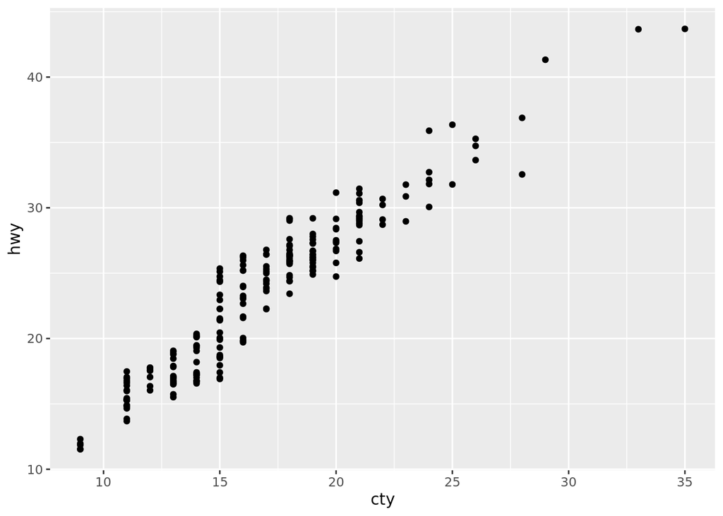

```r
ggplot(data = mpg, mapping = aes(x = cty, y = hwy)) +
  geom_jitter(height=0.5, width=0)
```

**3. Compare and contrast `geom_jitter()` and `geom_count`.**

`geom_count()` does not apply random noise to ploted data, but rather it counts the number of over-plotted points at a location and modifies the graph to illustrate the degree of over-plotting. The figure below shows the ue of `geom_count()` which seems to produce more of a density plot.

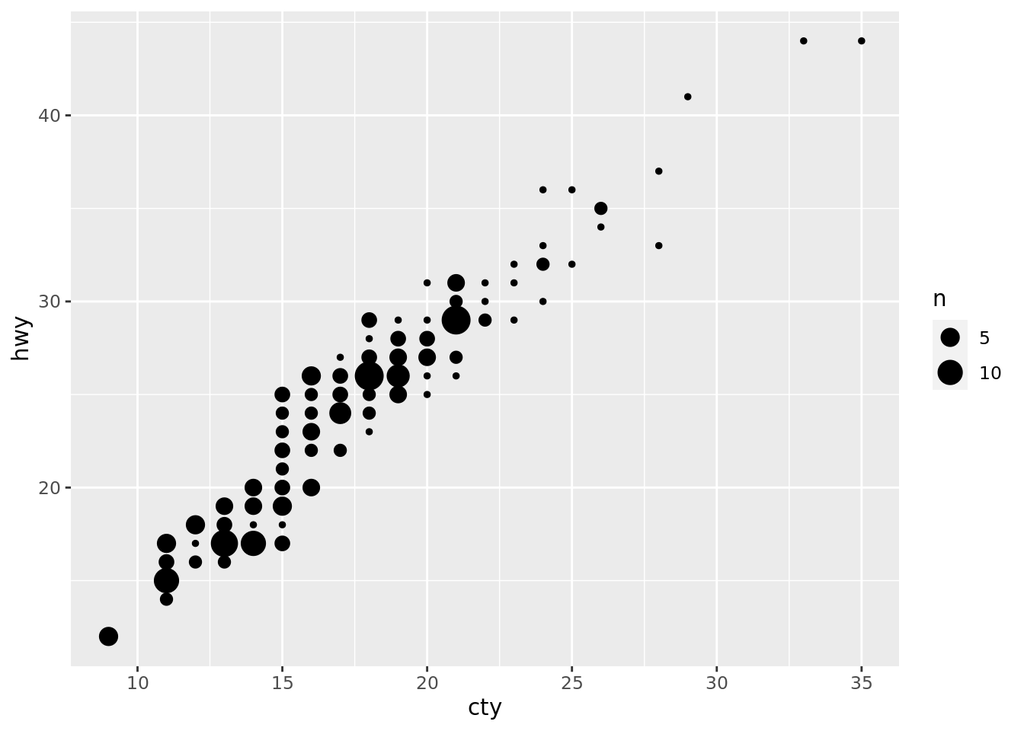

```r
ggplot(data = mpg, mapping = aes(x = cty, y = hwy)) +
  geom_count()
```

**4. What’s the default position adjustment for `geom_boxplot()`? Create a visualization of the `mpg` dataset that demonstrates it.**

The default is noted as `dodge2` in the help file. Digging further, `position_dodge2` is a special case of `position_dodge` for arranging boxplots which can have variable widths.

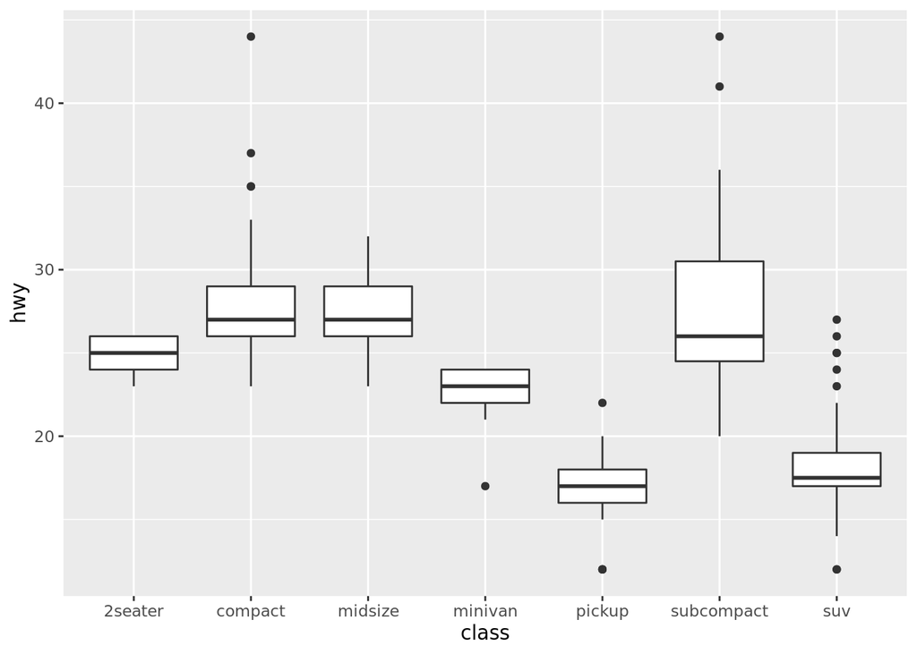

```r
ggplot(data = mpg, mapping = aes(x = class, y = hwy)) +
  geom_boxplot()
```

### 3.9.1 Exercises

**1. Turn a stacked bar chart into a pie chart using `coord_polar()`.**

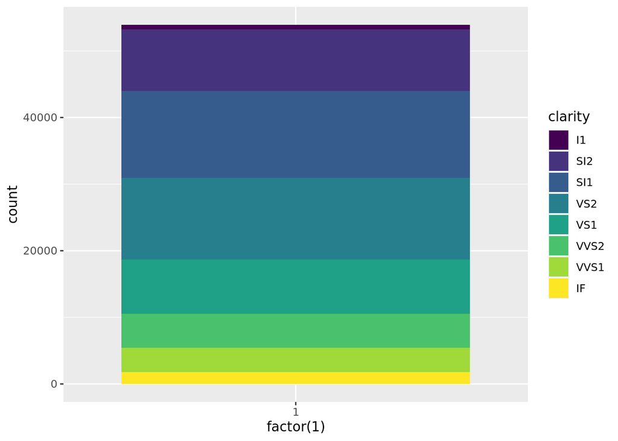

```r
ggplot(data = diamonds) +
  geom_bar(mapping = aes(x = factor(1), fill = clarity))
```

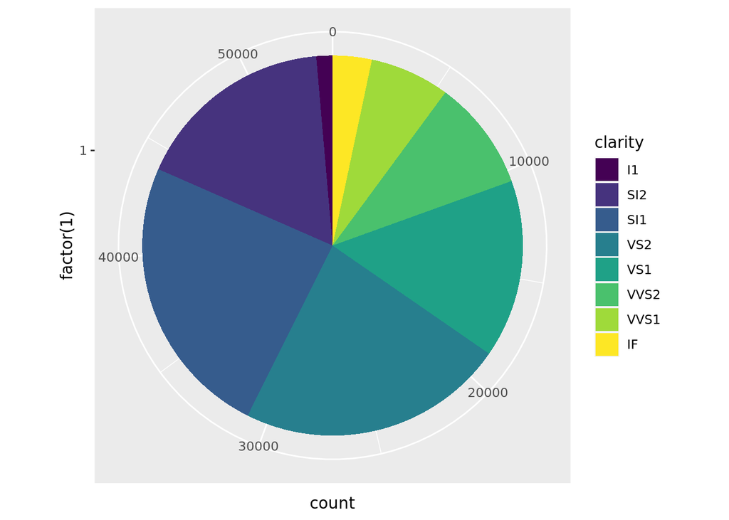

```r
ggplot(data = diamonds) +
  geom_bar(mapping = aes(x = factor(1), fill = clarity)) +
  coord_polar(theta = 'y') # need to include 'y' so that it maps correctly
```

**2. What does `labs()` do?**

`labs()` provides an interface to add labels to a plot.

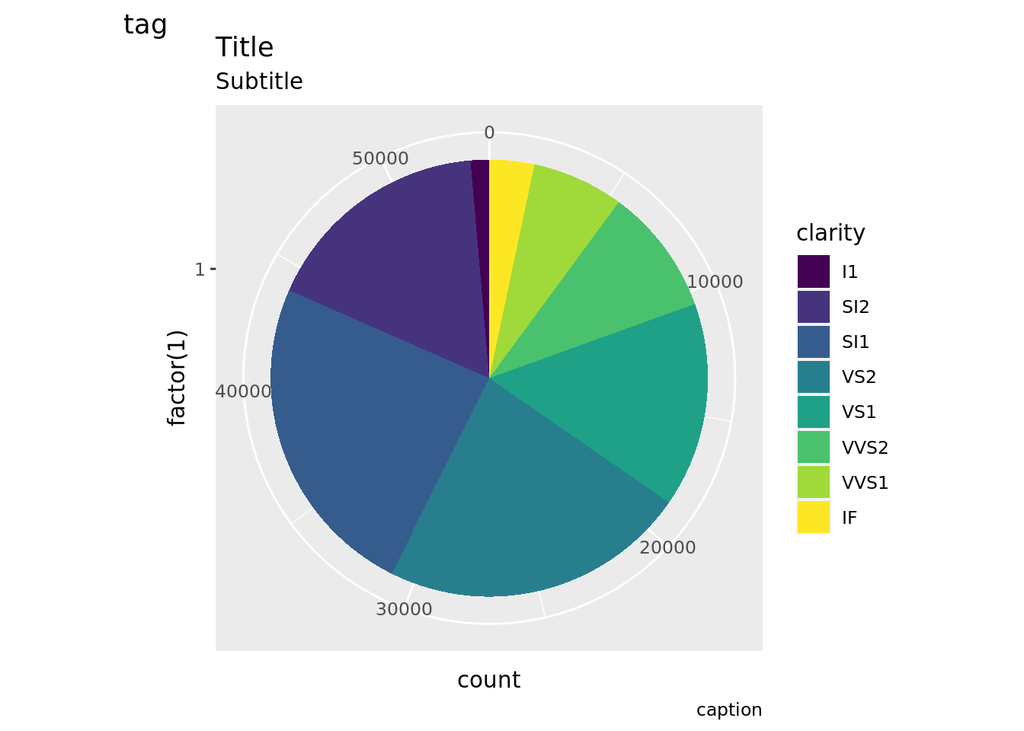

```r
ggplot(data = diamonds) +
  geom_bar(mapping = aes(x = factor(1), fill = clarity)) +
  coord_polar(theta = 'y') + # need to include 'y' so that it maps correctly
  labs(title = 'Title', subtitle = 'Subtitle', caption = 'caption', tag = 'tag')
```

**3. What’s the difference between `coord_quickmap()` and `coord_map()`?**

From the help files, “map projections must account for the fact taht the actual length (in km) of one degree of longitude varies between the equator and the pole…For regions that span only a few degrees and are not too close to the poles, setting the aspect ratio of the plot to the appropriate lat/lon ratio aprroximates the usual mercator projection. This is what `coord_quickmap` does, and is much faster at the expense of correctness.”

**4. What does the plot below tell you about the relationship between city and highway mpg? Whis is `coord_fixed()` important? What does `geom_abline()` do?**

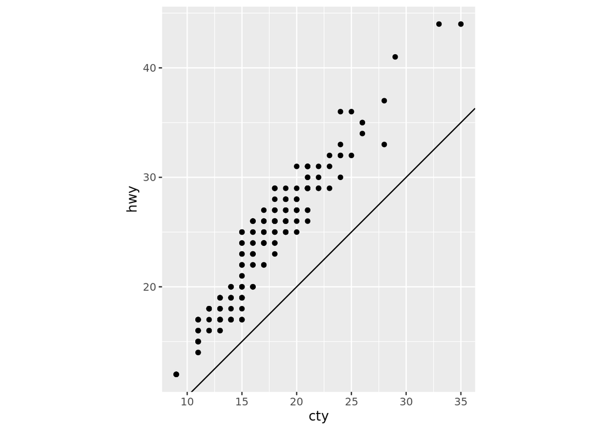

```r
ggplot(data = mpg, mapping = aes(x = cty, y = hwy)) +
  geom_point() +
  geom_abline() +
  coord_fixed()
```